# 2020 GREATER KAILASH(NEW DELHI CONSTITUENCY) ELECTION PREDICTIONS

```python
import pandas as pd
import numpy as np
import matplotlib.pyplot as plt
import matplotlib as mpl
mpl.style.use('seaborn')
%matplotlib inline
```

```python
df_15=pd.read_excel("AC-50-converted.xlsx",skiprows=5,skip_header=1)
```

```python
df_15.set_index("Unnamed: 0",inplace=True)
df_15.drop("Unnamed: 8",axis=1,inplace=True)
df_15.rename(columns={"Unnamed: 10":"Total valid Votes","Unnamed: 11":"No. of rejected votes (Test votes)","Unnamed: 12":"Votes for NOTA option ", "Unnamed: 13": "Total no. of tendered votes"},inplace=True)
df_15.index.name="Booth Number"
df_15.drop(df_15.index[-1],inplace=True)
df_15.tail(5)
```

| Booth Number | ADITYA (BSP) | RAKESH KUMAR GULLAIYA (BJP) | ROHIT TYAGI (NCP) | SHARMISTHA MUKHARJEE (INC) | SAURABH BHARADWAJ (AAP) | ASHOK KUMAR (SAMAJ PARIVARTAN PARTY) | ASHOK KUMAR SHARMA (SHIV SENA) | SANJAY KHATRI (INDEPENDENT) | Total valid Votes | No. of rejected votes (Test votes) | Votes for NOTA option | Total no. of tendered votes |
| --- | --- | --- | --- | --- | --- | --- | --- | --- | --- | --- | --- | --- |
| 152 | 0 | 391 | 0 | 54 | 242 | 4 | 0 | 0 | 691 | 0 | 3 | 0 |
| 153 | 0 | 150 | 0 | 18 | 116 | 0 | 0 | 0 | 284 | 0 | 0 | 0 |
| 154 | 1 | 372 | 0 | 42 | 248 | 2 | 0 | 1 | 666 | 0 | 3 | 0 |
| 155 | 0 | 205 | 0 | 18 | 149 | 0 | 1 | 3 | 376 | 0 | 2 | 0 |
| 156 | 1 | 333 | 4 | 44 | 374 | 2 | 0 | 1 | 759 | 0 | 4 | 0 |

```python
df_13=pd.read_excel("data.xlsx",skiprows=7)
```

```python
df_13.set_index("Unnamed: 0",inplace=True)
df_13.index.name="Booth Number"
df_13.rename(columns={"Unnamed: 7":"Total valid Votes","Unnamed: 8":"No. of rejected votes (Test votes)","Unnamed: 9":"Votes for NOTA option ", "Unnamed: 10": "Total no. of tendered votes"},inplace=True)
df_13.tail(5)
```

| Booth Number | Ajay Kumar Malhotra (BJP) | Mukesh Bhardwaj (BSP) | Virender Kasana (INC) | Nanhey Khan Qureshi (SP) | Saurabh Bharadwaj (AAP) | Ashok Kumar (INDEPENDENT) | Total valid Votes | No. of rejected votes (Test votes) | Votes for NOTA option | Total no. of tendered votes |
| --- | --- | --- | --- | --- | --- | --- | --- | --- | --- | --- |
| 152 | 260 | 1 | 135 | 1 | 240 | 2 | 639 | 0 | 4 | 0 |
| 153 | 80 | 0 | 50 | 1 | 126 | 0 | 257 | 0 | 2 | 0 |
| 154 | 203 | 0 | 132 | 2 | 285 | 2 | 624 | 0 | 4 | 0 |
| 155 | 127 | 1 | 63 | 1 | 179 | 0 | 371 | 0 | 3 | 0 |
| 156 | 208 | 6 | 166 | 1 | 314 | 2 | 697 | 0 | 5 | 0 |

### 2013 Data

```python
import re
s="ashok(bjp)"
```

```python
re.findall("[(](.*)[)]",s)[0]
```

```
'bjp'
```

```python
df_13.head()
```

| Booth Number | Ajay Kumar Malhotra (BJP) | Mukesh Bhardwaj (BSP) | Virender Kasana (INC) | Nanhey Khan Qureshi (SP) | Saurabh Bharadwaj (AAP) | Ashok Kumar (INDEPENDENT) | Total valid Votes | No. of rejected votes (Test votes) | Votes for NOTA option | Total no. of tendered votes |
| --- | --- | --- | --- | --- | --- | --- | --- | --- | --- | --- |
| 1 | 243 | 8 | 136 | 0 | 348 | 0 | 735 | 0 | 6 | 0 |
| 2 | 210 | 10 | 142 | 5 | 337 | 2 | 706 | 0 | 2 | 0 |
| 3 | 297 | 2 | 102 | 7 | 325 | 2 | 735 | 0 | 7 | 0 |
| 4 | 183 | 4 | 83 | 1 | 348 | 2 | 621 | 0 | 1 | 0 |
| 5 | 223 | 2 | 96 | 3 | 387 | 1 | 712 | 0 | 0 | 0 |

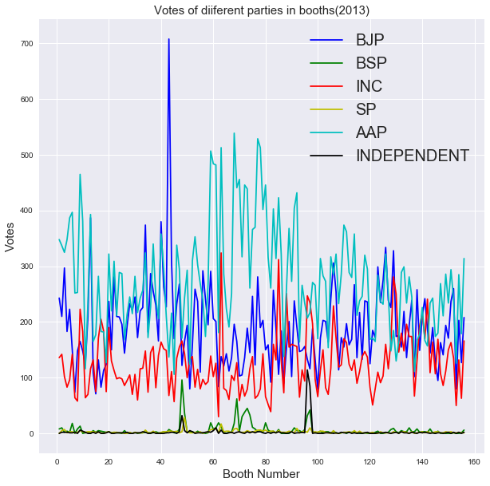

```python
fig,axis=plt.subplots(figsize=(10,10))
color=['b','g','r','y','c','k']
for i in range(6):
    axis.plot(df_13.index,df_13.iloc[:,i],c=color[i],label=re.findall("[(](.*)[)]",df_13.columns[i])[0])
plt.xlabel("Booth Number",fontsize=15)
plt.ylabel("Votes",fontsize=15)
plt.title("Votes of diiferent parties in booths(2013)",fontsize=15)
plt.legend(fontsize=20)
```

The plot shows that in most of the booths, AAP has the majority votes, but there are some booths where BJP and INC are ahead of AAP.

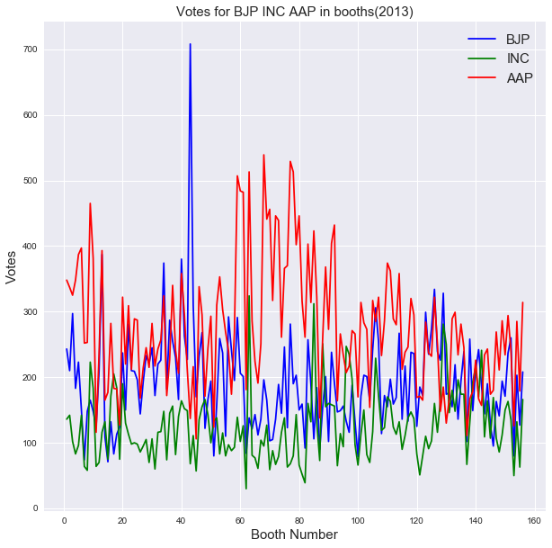

```python
fig,axis=plt.subplots(figsize=(10,10))
color=['b','g','r']
axis.plot(df_13.index,df_13.iloc[:,0],c=color[0],label=re.findall("[(](.*)[)]",df_13.columns[0])[0])
axis.plot(df_13.index,df_13.iloc[:,2],c=color[1],label=re.findall("[(](.*)[)]",df_13.columns[2])[0])
axis.plot(df_13.index,df_13.iloc[:,4],c=color[2],label=re.findall("[(](.*)[)]",df_13.columns[4])[0])
plt.xlabel("Booth Number",fontsize=15)
plt.ylabel("Votes",fontsize=15)
plt.title("Votes for BJP INC AAP in booths(2013)",fontsize=15)
axis.legend(fontsize=15)
```

```python
df_bjp_aap=df_13.copy()
df_bjp_aap["BJP-AAP"]=df_bjp_aap.iloc[:,0]-df_bjp_aap.iloc[:,4]
```

```
Text(0.5,1,'VOTE DIFFERENCE BJP-AAP(2013)')
```

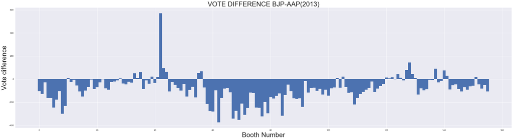

```python
fig,axis=plt.subplots(figsize=(40,10))
axis.bar(range(156),df_bjp_aap["BJP-AAP"],width=1)
axis.set_xlabel("Booth Number",fontsize=30)
axis.set_ylabel("Vote difference",fontsize=30)
axis.set_title("VOTE DIFFERENCE BJP-AAP(2013)",fontsize=30)
```

```python
df_inc_aap=df_13.copy()
df_inc_aap["INC-AAP"]=df_inc_aap.iloc[:,2]-df_inc_aap.iloc[:,4]
```

```
Text(0.5,1,'VOTE DIFFERENCE INC-AAP(2013)')
```

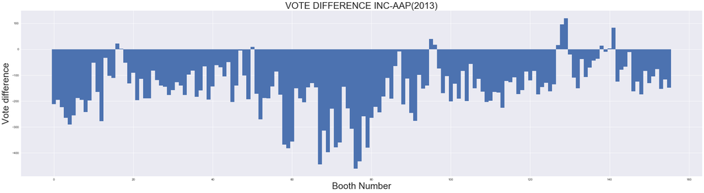

```python
fig,axis=plt.subplots(figsize=(40,10))
axis.bar(range(156),df_inc_aap["INC-AAP"],width=1)
axis.set_xlabel("Booth Number",fontsize=30)
axis.set_ylabel("Vote difference",fontsize=30)
axis.set_title("VOTE DIFFERENCE INC-AAP(2013)",fontsize=30)
```

### 2014 Data

```python
df_14=pd.read_excel("AC50(14)-converted.xlsx",skiprows=8)
```

```python
df_14.head()
```

|  | Unnamed: 0 | AJAY MAKAN (INC) | ASHISH KHETAN (AAP) | MEENAKASHI LEKHI (BJP) | SOLOMON GEORGE (BSP) | DEVI SINGH | DHEERAJ PURI | NAVEEN CHANDRA | PRADEEP VARMA | BISWAJIT RANJIT CHATTERJEE | ... | LUKMAN KHAN | VISHAL KHOSLA | VED PRAKASH | K P SANKARAN MENON | HARKRISHAN DAS NIJHAWAN | Unnamed: 32 | Unnamed: 33 | Unnamed: 34 | Unnamed: 35 | Unnamed: 36 |
| --- | --- | --- | --- | --- | --- | --- | --- | --- | --- | --- | --- | --- | --- | --- | --- | --- | --- | --- | --- | --- | --- |
| 0 | 1 | 180.0 | 226.0 | 553.0 | 13.0 | 0.0 | 0.0 | 0.0 | 0.0 | 1.0 | ... | 0.0 | 0.0 | 0.0 | 0.0 | 0.0 | 976.0 | 0.0 | 14.0 | 0.0 | NaN |
| 1 | 2 | 120.0 | 182.0 | 341.0 | 17.0 | 0.0 | 0.0 | 0.0 | 0.0 | 0.0 | ... | 0.0 | 0.0 | 0.0 | 0.0 | 0.0 | 691.0 | 0.0 | 1.0 | 0.0 | NaN |
| 2 | 3 | 95.0 | 139.0 | 482.0 | 5.0 | 0.0 | 0.0 | 1.0 | 0.0 | 8.0 | ... | 0.0 | 0.0 | 0.0 | 0.0 | 0.0 | 741.0 | 0.0 | 4.0 | 0.0 | NaN |
| 3 | 4 | 90.0 | 137.0 | 363.0 | 6.0 | 0.0 | 0.0 | 0.0 | 0.0 | 2.0 | ... | 0.0 | 0.0 | 0.0 | 0.0 | 0.0 | 615.0 | 0.0 | 2.0 | 0.0 | NaN |
| 4 | 5 | 97.0 | 154.0 | 475.0 | 1.0 | 0.0 | 0.0 | 0.0 | 0.0 | 3.0 | ... | 0.0 | 0.0 | 0.0 | 1.0 | 0.0 | 763.0 | 0.0 | 2.0 | 0.0 | NaN |

5 rows × 37 columns

```python
df_14.set_index("Unnamed: 0",inplace=True)
df_14.index.name="Booth Number"
df_14.rename(columns={"Unnamed: 32":"Total valid Votes","Unnamed: 33":"No. of rejected votes (Test votes)","Unnamed: 34":"Votes for NOTA option ", "Unnamed: 35": "Total no. of tendered votes"},inplace=True)
df_14.drop(["Unnamed: 10","Unnamed: 36"],axis=1,inplace=True)
df_14.drop(df_14.index[-6:-1],inplace=True,axis=0)
df_14.drop(df_14.index[-1],inplace=True,axis=0)
df_14.drop(list(df_14.columns[4:23])+list(df_14.columns[24:30]),axis=1,inplace=True)
df_14.tail(5)
```

| Booth Number | AJAY MAKAN (INC) | ASHISH KHETAN (AAP) | MEENAKASHI LEKHI (BJP) | SOLOMON GEORGE (BSP) | RAVI KUMAR GUPTA (IND) | Total valid Votes | No. of rejected votes (Test votes) | Votes for NOTA option | Total no. of tendered votes |
| --- | --- | --- | --- | --- | --- | --- | --- | --- | --- |
| 152 | 123.0 | 133.0 | 457.0 | 5.0 | 3.0 | 750.0 | 0.0 | 12.0 | 0.0 |
| 153 | 43.0 | 85.0 | 163.0 | 0.0 | 4.0 | 296.0 | 0.0 | 9.0 | 0.0 |
| 154 | 95.0 | 158.0 | 449.0 | 1.0 | 2.0 | 708.0 | 0.0 | 7.0 | 0.0 |
| 155 | 58.0 | 94.0 | 242.0 | 1.0 | 1.0 | 400.0 | 0.0 | 6.0 | 0.0 |
| 156 | 122.0 | 228.0 | 402.0 | 5.0 | 15.0 | 782.0 | 0.0 | 14.0 | 0.0 |

```
Text(0.5,1,'Votes distribution of major parties(2014)')
```

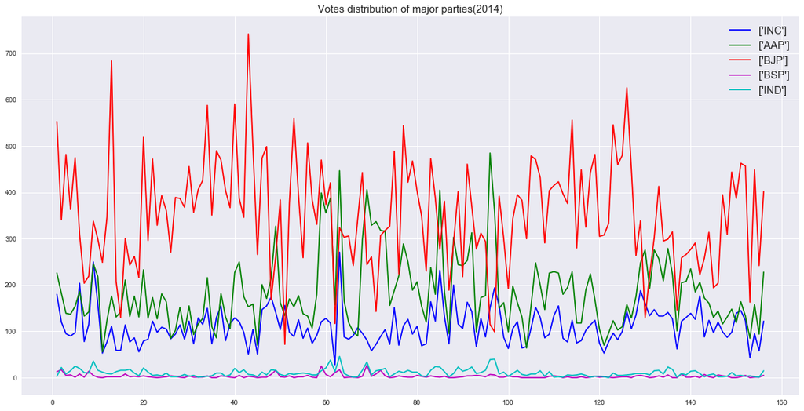

```python
plt.figure(figsize=(20,10))
color=['b','g','r','m','c']
for i in range(5):
    plt.plot(df_14.index,df_14.iloc[:,i],c=color[i],label=re.findall("[(](.*)[)]",df_14.columns[i]))
plt.legend(fontsize=15)
plt.title("Votes distribution of major parties(2014)",fontsize=15)
```

```python
df_14.columns
```

```
Index(['AJAY MAKAN (INC)', 'ASHISH KHETAN (AAP)', 'MEENAKASHI LEKHI (BJP)',
       'SOLOMON GEORGE (BSP)', 'RAVI KUMAR GUPTA (IND)', 'Total valid Votes',
       'No. of rejected votes (Test votes)', 'Votes for NOTA option ',
       'Total no. of tendered votes'],
      dtype='object')
```

```python
df_14.head()
```

| Booth Number | AJAY MAKAN (INC) | ASHISH KHETAN (AAP) | MEENAKASHI LEKHI (BJP) | SOLOMON GEORGE (BSP) | RAVI KUMAR GUPTA (IND) | Total valid Votes | No. of rejected votes (Test votes) | Votes for NOTA option | Total no. of tendered votes |
| --- | --- | --- | --- | --- | --- | --- | --- | --- | --- |
| 1 | 180.0 | 226.0 | 553.0 | 13.0 | 3.0 | 976.0 | 0.0 | 14.0 | 0.0 |
| 2 | 120.0 | 182.0 | 341.0 | 17.0 | 22.0 | 691.0 | 0.0 | 1.0 | 0.0 |
| 3 | 95.0 | 139.0 | 482.0 | 5.0 | 8.0 | 741.0 | 0.0 | 4.0 | 0.0 |
| 4 | 90.0 | 137.0 | 363.0 | 6.0 | 15.0 | 615.0 | 0.0 | 2.0 | 0.0 |
| 5 | 97.0 | 154.0 | 475.0 | 1.0 | 25.0 | 763.0 | 0.0 | 2.0 | 0.0 |

```python
df_bjp_aap_14=df_14.copy()
df_bjp_aap_14["diff"]=df_bjp_aap_14.iloc[:,2]-df_bjp_aap_14.iloc[:,1]
df_bjp_aap_14.head()
```

| Booth Number | AJAY MAKAN (INC) | ASHISH KHETAN (AAP) | MEENAKASHI LEKHI (BJP) | SOLOMON GEORGE (BSP) | RAVI KUMAR GUPTA (IND) | Total valid Votes | No. of rejected votes (Test votes) | Votes for NOTA option | Total no. of tendered votes | diff |
| --- | --- | --- | --- | --- | --- | --- | --- | --- | --- | --- |
| 1 | 180.0 | 226.0 | 553.0 | 13.0 | 3.0 | 976.0 | 0.0 | 14.0 | 0.0 | 327.0 |
| 2 | 120.0 | 182.0 | 341.0 | 17.0 | 22.0 | 691.0 | 0.0 | 1.0 | 0.0 | 159.0 |
| 3 | 95.0 | 139.0 | 482.0 | 5.0 | 8.0 | 741.0 | 0.0 | 4.0 | 0.0 | 343.0 |
| 4 | 90.0 | 137.0 | 363.0 | 6.0 | 15.0 | 615.0 | 0.0 | 2.0 | 0.0 | 226.0 |
| 5 | 97.0 | 154.0 | 475.0 | 1.0 | 25.0 | 763.0 | 0.0 | 2.0 | 0.0 | 321.0 |

```
Text(0.5,1,'VOTE DIFFERENCE BJP-AAP(2014)')
```

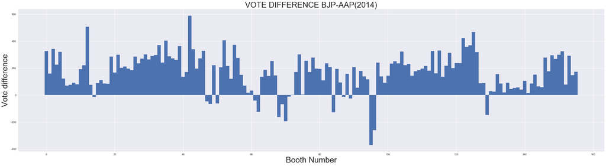

```python
fig,axis=plt.subplots(figsize=(40,10))
axis.bar(range(156),df_bjp_aap_14["diff"],width=1)
axis.set_xlabel("Booth Number",fontsize=30)
axis.set_ylabel("Vote difference",fontsize=30)
axis.set_title("VOTE DIFFERENCE BJP-AAP(2014)",fontsize=30)
```

### 2015 data

```python
df_15.head()
```

| Booth Number | ADITYA (BSP) | RAKESH KUMAR GULLAIYA (BJP) | ROHIT TYAGI (NCP) | SHARMISTHA MUKHARJEE (INC) | SAURABH BHARADWAJ (AAP) | ASHOK KUMAR (SAMAJ PARIVARTAN PARTY) | ASHOK KUMAR SHARMA (SHIV SENA) | SANJAY KHATRI (INDEPENDENT) | Total valid Votes | No. of rejected votes (Test votes) | Votes for NOTA option | Total no. of tendered votes |
| --- | --- | --- | --- | --- | --- | --- | --- | --- | --- | --- | --- | --- |
| 1 | 3 | 435 | 0 | 51 | 491 | 2 | 0 | 1 | 983 | 0 | 8 | 0 |
| 2 | 3 | 221 | 1 | 41 | 490 | 3 | 0 | 2 | 761 | 0 | 4 | 0 |
| 3 | 0 | 361 | 1 | 43 | 414 | 0 | 1 | 2 | 822 | 0 | 6 | 0 |
| 4 | 2 | 255 | 1 | 29 | 409 | 1 | 0 | 1 | 698 | 0 | 1 | 0 |
| 5 | 0 | 345 | 1 | 51 | 434 | 0 | 0 | 0 | 831 | 0 | 1 | 0 |

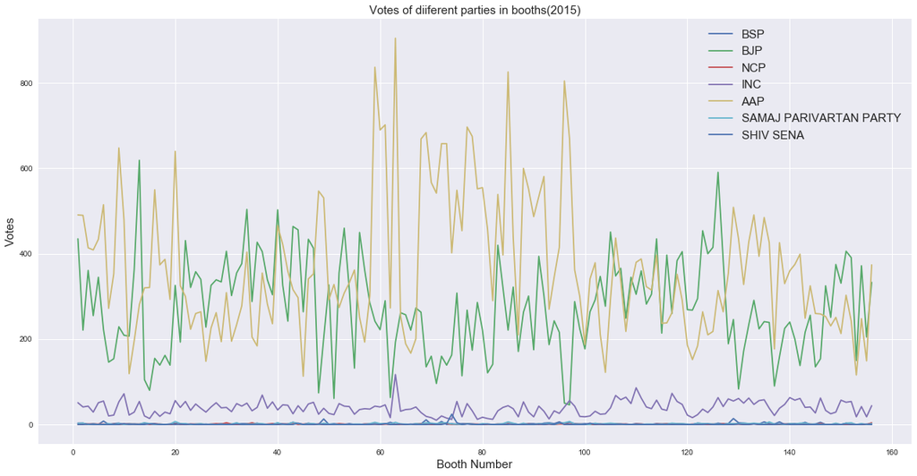

```python
fig,axis=plt.subplots(figsize=(20,10))
color=['C0','C1','C2','C3','C4','C5','C6','C7']
for i in range(7):
    axis.plot(df_15.index,df_15.iloc[:,i],c=color[i],label=re.findall("[(](.*)[)]",df_15.columns[i])[0])
plt.xlabel("Booth Number",fontsize=15)
plt.ylabel("Votes",fontsize=15)
plt.title("Votes of diiferent parties in booths(2015)",fontsize=15)
plt.legend(fontsize=15,loc="best")
```

THE Graph shows that the majority votes are given to either AAP or BJP.

```python
df_bjp_aap_15=df_15.copy()
df_bjp_aap_15["BJP-AAP"]=df_bjp_aap_15.iloc[:,1]-df_bjp_aap_15.iloc[:,4]
```

```
Text(0.5,1,'VOTE DIFFERENCE BJP-AAP(2015)')
```

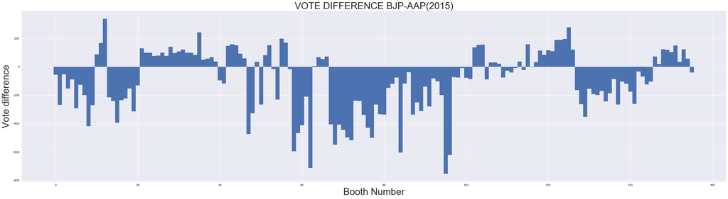

```python
fig,axis=plt.subplots(figsize=(40,10))
axis.bar(range(156),df_bjp_aap_15["BJP-AAP"],width=1)
axis.set_xlabel("Booth Number",fontsize=30)
axis.set_ylabel("Vote difference",fontsize=30)
axis.set_title("VOTE DIFFERENCE BJP-AAP(2015)",fontsize=30)
```

### BJP AAP Vote change from 2013 to 2015

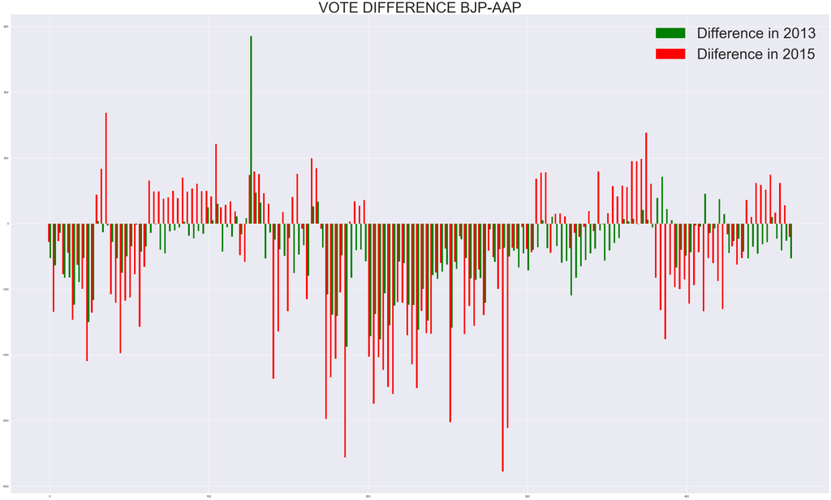

```python
fig,axis=plt.subplots(figsize=(50,30))
width=1
ind=np.linspace(0,3*155,156)
axis.bar(ind+width/2,df_bjp_aap["BJP-AAP"],label="Difference in 2013",color='green',width=width)
axis.bar(ind-width/2,df_bjp_aap_15["BJP-AAP"],label="Diiference in 2015",color='red',width=width)
axis.set_title("VOTE DIFFERENCE BJP-AAP",fontsize=50)
axis.legend(loc="best",fontsize=50)
```

```python
df_13_15_bjp_aap=pd.DataFrame()
df_13_15_bjp_aap["bjp_13"]=df_13.iloc[:,0]
df_13_15_bjp_aap["aap_13"]=df_13.iloc[:,4]
df_13_15_bjp_aap["bjp_15"]=df_15.iloc[:,1]
df_13_15_bjp_aap["aap_15"]=df_15.iloc[:,4]


df_13_15_bjp_aap.head()
```

| Booth Number | bjp_13 | aap_13 | bjp_15 | aap_15 |
| --- | --- | --- | --- | --- |
| 1 | 243 | 348 | 435 | 491 |
| 2 | 210 | 337 | 221 | 490 |
| 3 | 297 | 325 | 361 | 414 |
| 4 | 183 | 348 | 255 | 409 |
| 5 | 223 | 387 | 345 | 434 |

```python
df_13_15_bjp_aap["bjp13-aap13"]=df_13_15_bjp_aap["bjp_13"]-df_13_15_bjp_aap["aap_13"]
df_13_15_bjp_aap["bjp15-aap15"]=df_13_15_bjp_aap["bjp_15"]-df_13_15_bjp_aap["aap_15"]

df_13_15_bjp_aap["% change in difference(15-13)"]=(df_13_15_bjp_aap["bjp15-aap15"]-df_13_15_bjp_aap["bjp13-aap13"])*100/abs(df_13_15_bjp_aap["bjp13-aap13"])
```

```python
df_13_15_bjp_aap.head()
```

| Booth Number | bjp_13 | aap_13 | bjp_15 | aap_15 | bjp13-aap13 | bjp15-aap15 | % change in difference(15-13) |
| --- | --- | --- | --- | --- | --- | --- | --- |
| 1 | 243 | 348 | 435 | 491 | -105 | -56 | 46.666667 |
| 2 | 210 | 337 | 221 | 490 | -127 | -269 | -111.811024 |
| 3 | 297 | 325 | 361 | 414 | -28 | -53 | -89.285714 |
| 4 | 183 | 348 | 255 | 409 | -165 | -154 | 6.666667 |
| 5 | 223 | 387 | 345 | 434 | -164 | -89 | 45.731707 |

```python
df_13_15_bjp_aap["% change in difference(15-13)"].describe()
```

```
count     156.000000
mean      152.905897
std      1180.522696
min     -5033.333333
25%      -102.133621
50%        34.206742
75%       211.394231
max      9600.000000
Name: % change in difference(15-13), dtype: float64
```

```python
### % Change in difference >+100 means that the difference now has reversed (earlier bjp was lacking but now bjp is in lead ) or bjp was already in lead and now in much more lead.
```

```python
indices=np.where(df_13_15_bjp_aap["% change in difference(15-13)"]>100)
print("Booths-", indices[0]+1)
```

```
Booths- [ 11  12  13  22  23  24  25  26  27  28  29  30  31  32  33  35  36  37
  38  39  45  46  47  50  52  53  56  57  64  65  66  67 103 104 105 107
 108 109 114 116 118 119 120 121 122 123 124 125 126 127 147 148 149 150
 151 152 153 154 155]
```

```
Text(0.5,1,'VOTE DIFFERENCE (percentage change) BJP-AAP(2015-13)')
```

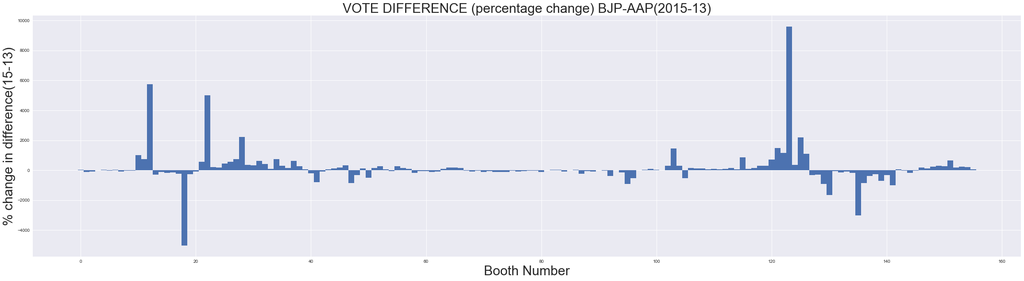

```python
fig,axis=plt.subplots(figsize=(40,10))
axis.bar(range(156),df_13_15_bjp_aap["% change in difference(15-13)"],width=1)
axis.set_xlabel("Booth Number",fontsize=30)
axis.set_ylabel("% change in difference(15-13)",fontsize=30)
axis.set_title("VOTE DIFFERENCE (percentage change) BJP-AAP(2015-13)",fontsize=30)
```

```
[Text(0,0,'0'),
 Text(0,0,'100'),
 Text(0,0,'200'),
 Text(0,0,'300'),
 Text(0,0,'400'),
 Text(0,0,'500'),
 Text(0,0,'600')]
```

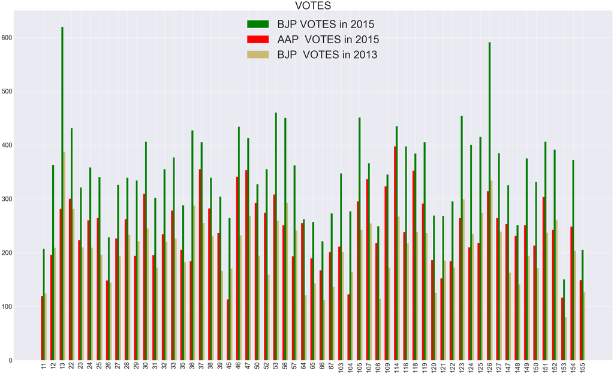

```python
fig,axis=plt.subplots(figsize=(50,30))
width=3
ind=np.linspace(0,15*58,59)
axis.bar(ind,df_15.iloc[:,1][indices[0]+1],label="BJP VOTES in 2015",color='green',width=width)
axis.bar(ind-width,df_15.iloc[:,4][indices[0]+1],label="AAP  VOTES in 2015",color='red',width=width)
axis.bar(ind+width,df_13.iloc[:,0][indices[0]+1],label="BJP  VOTES in 2013",color='C4',width=width)

axis.set_title("VOTES",fontsize=50)
axis.legend(loc="best",fontsize=50)

axis.set_xticks(ind)
axis.set_xticklabels(indices[0]+1,rotation=90,fontsize=30)
axis.set_yticklabels(range(0,601,100),fontsize=30)
```

```python
indicesR=np.where(df_13_15_bjp_aap["% change in difference(15-13)"]<-100)
```

```python
df_13_15_bjp_aap.iloc[indicesR[0],:].head()
```

| Booth Number | bjp_13 | aap_13 | bjp_15 | aap_15 | bjp13-aap13 | bjp15-aap15 | % change in difference(15-13) |
| --- | --- | --- | --- | --- | --- | --- | --- |
| 2 | 210 | 337 | 221 | 490 | -127 | -269 | -111.811024 |
| 14 | 109 | 165 | 105 | 320 | -56 | -215 | -283.928571 |
| 15 | 71 | 177 | 80 | 321 | -106 | -241 | -127.358491 |
| 16 | 132 | 282 | 155 | 550 | -150 | -395 | -163.333333 |
| 17 | 83 | 183 | 139 | 374 | -100 | -235 | -135.000000 |

```python
len(indicesR[0])
```

```
40
```

```python
print("Booths",indicesR[0]+1)
```

```
Booths [  2  14  15  16  17  18  19  20  41  42  48  49  51  59  62  71  73  74
  75  81  88  93  95  96  97 106 128 129 130 131 133 135 136 137 138 139
 140 141 142 145]
```

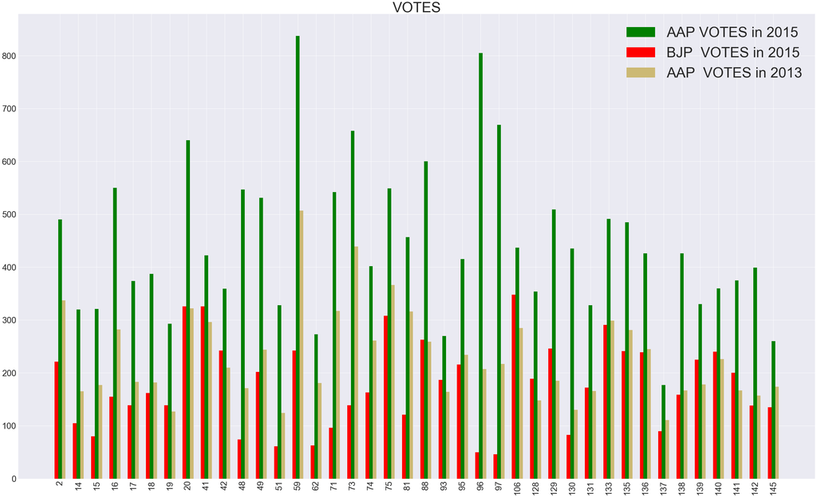

```python
fig,axis=plt.subplots(figsize=(50,30))
width=3
ind=np.linspace(0,15*39,40)
axis.bar(ind,df_15.iloc[:,4][indicesR[0]+1],label="AAP VOTES in 2015",color='green',width=width)
axis.bar(ind-width,df_15.iloc[:,1][indicesR[0]+1],label="BJP  VOTES in 2015",color='red',width=width)
axis.bar(ind+width,df_13.iloc[:,4][indicesR[0]+1],label="AAP  VOTES in 2013",color='C4',width=width)

axis.set_title("VOTES",fontsize=50)


axis.set_xticks(ind)
axis.set_xticklabels(indicesR[0]+1,rotation=90,fontsize=30)
axis.set_yticklabels(range(0,801,100),fontsize=30)
axis.legend(loc="best",fontsize=50)
```

```python
df_13_15_bjp_aap.iloc[42,:]
```

```
bjp_13                           708.00000
aap_13                           137.00000
bjp_15                           464.00000
aap_15                           316.00000
bjp13-aap13                      571.00000
bjp15-aap15                      148.00000
% change in difference(15-13)    -74.08056
Name: 43, dtype: float64
```

```python
### % change in difference between 0 to 100 means bjp's difference in votes has decreased . These booth areas need further analysis
### Opposite is the difference between 0 to -100 .
```

```python
### Till now booths where the majority was reversed or the difference in majority for one party has further increased(by more than 100%) are analysed.
```

```python
### Analyze booths where the difference of AAP/BJP has increased more but maybe not more than 100%.
```

```python
## Can note the names of candidates in who's election, majority got reversed (in favor) . Can check (not in favor also.. i.e bad candidate)
```

### Summary of vote differences over the years (BJP-AAP)

```
Text(0.5,1,'VOTE DIFFERENCE BJP-AAP(2015)')
```

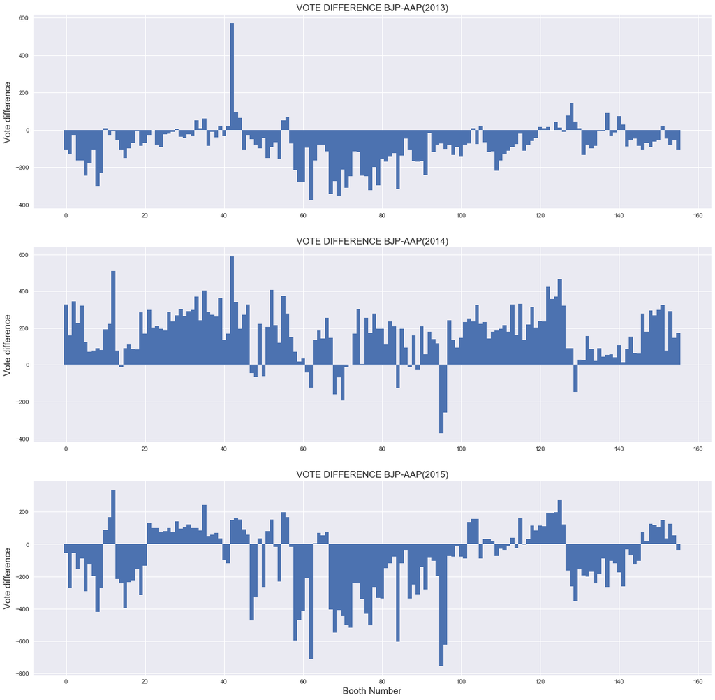

```python
fig,axis=plt.subplots(3,1,figsize=(20,20))



axis[0].bar(range(156),df_bjp_aap["BJP-AAP"],width=1)

axis[0].set_ylabel("Vote difference",fontsize=15)
axis[0].set_title("VOTE DIFFERENCE BJP-AAP(2013)",fontsize=15)


axis[1].bar(range(156),df_bjp_aap_14["diff"],width=1)

axis[1].set_ylabel("Vote difference",fontsize=15)
axis[1].set_title("VOTE DIFFERENCE BJP-AAP(2014)",fontsize=15)



axis[2].bar(range(156),df_bjp_aap_15["BJP-AAP"],width=1)
axis[2].set_xlabel("Booth Number",fontsize=15)
axis[2].set_ylabel("Vote difference",fontsize=15)
axis[2].set_title("VOTE DIFFERENCE BJP-AAP(2015)",fontsize=15)
```

### 2009 Data

```python
df_09=pd.read_excel("df09.xlsx",skiprows=1)
df_09.head()
```

|  | Unnamed: 0 | Unnamed: 1 | Ajay Makan (INC) | Trilok chand Sharma(BSP) | Vijay Goel (BJP) | Aamer Ahmed Madni (SP) | Jitendar Kumar Gupta | Naresh Chander Pal | Nisha Bano | Maharaj Kumar | ... | Ved Prakash | Shiban Krishan Razdan | Shiv Kumar Shah | Sapna Rani Behl | Surender Singh Dabas | Harkrisha n Das Nijhawan | Unnamed: 42 | Unnamed: 43 | Unnamed: 44 | Unnamed: 45 |
| --- | --- | --- | --- | --- | --- | --- | --- | --- | --- | --- | --- | --- | --- | --- | --- | --- | --- | --- | --- | --- | --- |
| 0 | NaN | NaN | 1 | 2 | 3 | 4 | 5 | 6 | 7 | 8 | ... | 35 | 36 | 37 | 38 | 39 | 40 | NaN | NaN | NaN | NaN |
| 1 | 1 | 1 | 330 | 2 | 186 | 3 | 1 | 1 | 0 | 0 | ... | 0 | 0 | 0 | 0 | 0 | 0 | 533.0 | 0.0 | 533.0 | 0.0 |
| 2 | 2 | 2 | 205 | 6 | 138 | 0 | 0 | 0 | 0 | 0 | ... | 0 | 0 | 0 | 0 | 0 | 0 | 358.0 | 0.0 | 358.0 | 0.0 |
| 3 | 3 | 3 | 279 | 102 | 206 | 0 | 0 | 1 | 0 | 0 | ... | 0 | 1 | 0 | 1 | 1 | 1 | 611.0 | 0.0 | 611.0 | 0.0 |
| 4 | 4 | 4 | 108 | 3 | 114 | 0 | 0 | 0 | 0 | 0 | ... | 0 | 0 | 0 | 0 | 0 | 0 | 229.0 | 0.0 | 229.0 | 0.0 |

5 rows × 46 columns

```python
df_09.drop(["Unnamed: 0"],axis=1,inplace=True)
```

```python
df_09.drop(df_09.index[0],axis=0,inplace=True)
df_09.set_index("Unnamed: 1",inplace=True)
df_09.index.name="Booth Number"
df_09.rename(columns={"Unnamed: 42":"Total valid Votes","Unnamed: 43":"No. of rejected votes (Test votes)","Unnamed: 44":"Votes for NOTA option ", "Unnamed: 45": "Total no. of tendered votes"},inplace=True)
# df_09.drop(["Unnamed: 10","Unnamed: 36"],axis=1,inplace=True)
# df_09.drop(df_14.index[-6:-1],inplace=True,axis=0)
df_09.drop(df_09.index[-1],inplace=True,axis=0)
df_09.drop(list(df_09.columns[4:40]),inplace=True,axis=1)
df_09.tail(5)
```

| Booth Number | Ajay Makan (INC) | Trilok chand Sharma(BSP) | Vijay Goel (BJP) | Aamer Ahmed Madni (SP) | Total valid Votes | No. of rejected votes (Test votes) | Votes for NOTA option | Total no. of tendered votes |
| --- | --- | --- | --- | --- | --- | --- | --- | --- |
| 155 | 174 | 0 | 146 | 1 | 323.0 | 0.0 | 323.0 | 0.0 |
| 156 | 157 | 2 | 141 | 1 | 308.0 | 0.0 | 308.0 | 0.0 |
| 157 | 381 | 5 | 276 | 2 | 669.0 | 0.0 | 669.0 | 0.0 |
| 158 | 191 | 0 | 183 | 2 | 388.0 | 0.0 | 388.0 | 0.0 |
| 159 | 433 | 35 | 245 | 1 | 721.0 | 0.0 | 721.0 | 0.0 |

```python
for i in df_09.index:
    if 'A' in str(i):
        df_09.drop(i,axis=0,inplace=True)
df_09.drop(df_09.index[-3:-1],inplace=True,axis=0)
```

```python
df_09.drop(df_09.index[-1],inplace=True,axis=0)
```

```python
def winner(row):
    return re.findall("[(](.*)[)]",df_09.columns[np.where(row==np.max(row[df_09.columns[0:4]]))[0][0]])[0]

df_09["winner"]=df_09.apply(winner,axis=1)
df_09.head()
```

| Booth Number | Ajay Makan (INC) | Trilok chand Sharma(BSP) | Vijay Goel (BJP) | Aamer Ahmed Madni (SP) | Total valid Votes | No. of rejected votes (Test votes) | Votes for NOTA option | Total no. of tendered votes | winner |
| --- | --- | --- | --- | --- | --- | --- | --- | --- | --- |
| 1 | 330 | 2 | 186 | 3 | 533.0 | 0.0 | 533.0 | 0.0 | INC |
| 2 | 205 | 6 | 138 | 0 | 358.0 | 0.0 | 358.0 | 0.0 | INC |
| 3 | 279 | 102 | 206 | 0 | 611.0 | 0.0 | 611.0 | 0.0 | INC |
| 4 | 108 | 3 | 114 | 0 | 229.0 | 0.0 | 229.0 | 0.0 | BJP |
| 5 | 198 | 3 | 174 | 2 | 389.0 | 0.0 | 389.0 | 0.0 | INC |

```python
df_09["winner"].value_counts()
```

```
INC    145
BJP     11
Name: winner, dtype: int64
```

```python
def winner(row):
    return re.findall("[(](.*)[)]",df_15.columns[np.where(row==np.max(row[df_15.columns[0:8]]))[0][0]])[0]
df_15["winner"]=df_15.apply(winner,axis=1)
```

```python
df_15.head()
```

| Booth Number | ADITYA (BSP) | RAKESH KUMAR GULLAIYA (BJP) | ROHIT TYAGI (NCP) | SHARMISTHA MUKHARJEE (INC) | SAURABH BHARADWAJ (AAP) | ASHOK KUMAR (SAMAJ PARIVARTAN PARTY) | ASHOK KUMAR SHARMA (SHIV SENA) | SANJAY KHATRI (INDEPENDENT) | Total valid Votes | No. of rejected votes (Test votes) | Votes for NOTA option | Total no. of tendered votes | winner |
| --- | --- | --- | --- | --- | --- | --- | --- | --- | --- | --- | --- | --- | --- |
| 1 | 3 | 435 | 0 | 51 | 491 | 2 | 0 | 1 | 983 | 0 | 8 | 0 | AAP |
| 2 | 3 | 221 | 1 | 41 | 490 | 3 | 0 | 2 | 761 | 0 | 4 | 0 | AAP |
| 3 | 0 | 361 | 1 | 43 | 414 | 0 | 1 | 2 | 822 | 0 | 6 | 0 | AAP |
| 4 | 2 | 255 | 1 | 29 | 409 | 1 | 0 | 1 | 698 | 0 | 1 | 0 | AAP |
| 5 | 0 | 345 | 1 | 51 | 434 | 0 | 0 | 0 | 831 | 0 | 1 | 0 | AAP |

```python
df_15["winner"].value_counts()
```

```
AAP    93
BJP    63
Name: winner, dtype: int64
```

```python
def winner(row):
    return re.findall("[(](.*)[)]",df_13.columns[np.where(row==np.max(row[df_13.columns[0:6]]))[0][0]])[0]
df_13["winner"]=df_13.apply(winner,axis=1)
df_13.head()
```

| Booth Number | Ajay Kumar Malhotra (BJP) | Mukesh Bhardwaj (BSP) | Virender Kasana (INC) | Nanhey Khan Qureshi (SP) | Saurabh Bharadwaj (AAP) | Ashok Kumar (INDEPENDENT) | Total valid Votes | No. of rejected votes (Test votes) | Votes for NOTA option | Total no. of tendered votes | winner |
| --- | --- | --- | --- | --- | --- | --- | --- | --- | --- | --- | --- |
| 1 | 243 | 8 | 136 | 0 | 348 | 0 | 735 | 0 | 6 | 0 | AAP |
| 2 | 210 | 10 | 142 | 5 | 337 | 2 | 706 | 0 | 2 | 0 | AAP |
| 3 | 297 | 2 | 102 | 7 | 325 | 2 | 735 | 0 | 7 | 0 | AAP |
| 4 | 183 | 4 | 83 | 1 | 348 | 2 | 621 | 0 | 1 | 0 | AAP |
| 5 | 223 | 2 | 96 | 3 | 387 | 1 | 712 | 0 | 0 | 0 | AAP |

```python
df_13["winner"].value_counts()
```

```
AAP    123
BJP     25
INC      8
Name: winner, dtype: int64
```

```python
def winner(row):
    return re.findall("[(](.*)[)]",df_14.columns[np.where(row==np.max(row[df_14.columns[0:5]]))[0][0]])[0]

df_14["winner"]=df_14.apply(winner,axis=1)
df_14.head()
```

| Booth Number | AJAY MAKAN (INC) | ASHISH KHETAN (AAP) | MEENAKASHI LEKHI (BJP) | SOLOMON GEORGE (BSP) | RAVI KUMAR GUPTA (IND) | Total valid Votes | No. of rejected votes (Test votes) | Votes for NOTA option | Total no. of tendered votes | winner |
| --- | --- | --- | --- | --- | --- | --- | --- | --- | --- | --- |
| 1 | 180.0 | 226.0 | 553.0 | 13.0 | 3.0 | 976.0 | 0.0 | 14.0 | 0.0 | BJP |
| 2 | 120.0 | 182.0 | 341.0 | 17.0 | 22.0 | 691.0 | 0.0 | 1.0 | 0.0 | BJP |
| 3 | 95.0 | 139.0 | 482.0 | 5.0 | 8.0 | 741.0 | 0.0 | 4.0 | 0.0 | BJP |
| 4 | 90.0 | 137.0 | 363.0 | 6.0 | 15.0 | 615.0 | 0.0 | 2.0 | 0.0 | BJP |
| 5 | 97.0 | 154.0 | 475.0 | 1.0 | 25.0 | 763.0 | 0.0 | 2.0 | 0.0 | BJP |

```python
df_14["winner"].value_counts()
```

```
BJP    140
AAP     15
INC      1
Name: winner, dtype: int64
```

```python
np.where(df_13["winner"]==df_14["winner"])
```

```
(array([ 10,  14,  28,  33,  34,  35,  39,  41,  42,  43,  44,  47,  48,
         50,  55,  56,  61,  62,  68,  69,  70,  71,  84,  87,  89, 103,
        105, 120, 121, 122, 124, 125, 127, 128, 130, 137, 140, 151],
       dtype=int64),)
```

```python
np.where(df_15["winner"]==df_14["winner"])
```

```
(array([ 10,  11,  12,  14,  21,  22,  23,  24,  25,  26,  27,  28,  29,
         30,  31,  32,  33,  34,  35,  36,  37,  38,  39,  42,  43,  44,
         45,  46,  47,  48,  49,  51,  52,  55,  56,  61,  62,  63,  64,
         65,  66,  68,  69,  70,  71,  84,  87,  89,  95,  96, 102, 103,
        104, 106, 107, 108, 113, 115, 117, 118, 119, 120, 121, 122, 123,
        124, 125, 126, 129, 146, 147, 148, 149, 150, 151, 152, 153, 154],
       dtype=int64),)
```

```python
np.where(df_13["winner"]==df_09["winner"])
```

```
(array([ 16,  17,  50,  96, 122, 129, 138, 141], dtype=int64),)
```

#### An Important point to note is that from 2013, INC has lost almost all of their votes. Before 2013, AAP was not formed, and from 2013, they have taken away the votes of INC . In 2014 INC has got only 1 booth while in 2015, they didn't even get a single one.

### Hence, it is more logical to consider the party which has won the PAST 3 ELECTIONS (excluding 2009).

```python
### What I think is , being such an influencial party in greater kailash, since AAP was not there in 2009 , annd the vote bank was just distributed among njpp and inc and getting to know that aap has taken up votes of inc, the analysis should be majorly be focussed on the past 3 years.
```

```python
### Like it is more sensible to analysize how the vote pattern has been since the existance of AAP as the situation has changed completely since its emergence.(Before 2013 is not much of a use)
```

```python
same=[]
for i in np.where(df_13["winner"]==df_14["winner"])[0]:
    if i in np.where(df_15["winner"]==df_14["winner"])[0]:
        same.append(i+1)
print("Booths where the same Party is winning for the past 3 years\n \n" , same )
```

```
Booths where the same Party is winning for the past 3 years

 [11, 15, 29, 34, 35, 36, 40, 43, 44, 45, 48, 49, 56, 57, 62, 63, 69, 70, 71, 72, 85, 88, 90, 104, 121, 122, 123, 125, 126, 152]
```

```python
print("Booth\t Party winning for past 3 years\n")
for i in same:
    print(i,"\t\t",df_15.loc[i,"winner"])
```

```
Booth	 Party winning for past 3 years

11 		 BJP
15 		 AAP
29 		 BJP
34 		 BJP
35 		 BJP
36 		 BJP
40 		 BJP
43 		 BJP
44 		 BJP
45 		 BJP
48 		 AAP
49 		 AAP
56 		 BJP
```

[output cut: 17 more lines]

#### ---------------------------------------------------------------------------------------------------------------------------

#### These parties would probably continue to support their respective parties in 2020 also.

#### ----------------------------------------------------------------------------------------------------------------------------

### 2014-2013 change

```python
df_bjp_aap_13_14=pd.DataFrame()
df_bjp_aap_13_14["bjp13"]=df_13.iloc[:,0]
df_bjp_aap_13_14["aap13"]=df_13.iloc[:,4]
df_bjp_aap_13_14["bjp14"]=df_14.iloc[:,2]
df_bjp_aap_13_14["aap14"]=df_14.iloc[:,1]
df_bjp_aap_13_14["bjp-aap13"]=df_bjp_aap_13_14["bjp13"]-df_bjp_aap_13_14["aap13"]
df_bjp_aap_13_14["bjp-aap14"]=df_bjp_aap_13_14["bjp14"]-df_bjp_aap_13_14["aap14"]
df_bjp_aap_13_14["% change in diff 2014-2013"]=(df_bjp_aap_13_14["bjp-aap14"]-df_bjp_aap_13_14["bjp-aap13"])*100/abs(df_bjp_aap_13_14["bjp-aap13"])
```

```python
df_bjp_aap_13_14.head()
```

| Booth Number | bjp13 | aap13 | bjp14 | aap14 | bjp-aap13 | bjp-aap14 | % change in diff 2014-2013 |
| --- | --- | --- | --- | --- | --- | --- | --- |
| 1 | 243 | 348 | 553.0 | 226.0 | -105 | 327.0 | 411.428571 |
| 2 | 210 | 337 | 341.0 | 182.0 | -127 | 159.0 | 225.196850 |
| 3 | 297 | 325 | 482.0 | 139.0 | -28 | 343.0 | 1325.000000 |
| 4 | 183 | 348 | 363.0 | 137.0 | -165 | 226.0 | 236.969697 |
| 5 | 223 | 387 | 475.0 | 154.0 | -164 | 321.0 | 295.731707 |

```
Text(0,0.5,'% change')
```

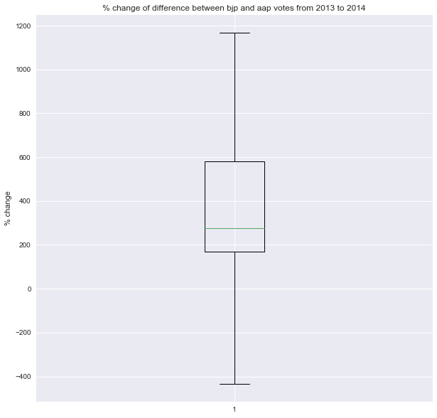

```python
plt.figure(figsize=(10,10))
plt.boxplot(df_bjp_aap_13_14["% change in diff 2014-2013"],whis=None,showfliers=False)
plt.title("% change of difference between bjp and aap votes from 2013 to 2014")
plt.ylabel("% change")
```

### 2015-2014 change

```python
df_bjp_aap_14_15=pd.DataFrame()


df_bjp_aap_14_15["bjp14"]=df_14.iloc[:,2]
df_bjp_aap_14_15["aap14"]=df_14.iloc[:,1]

df_bjp_aap_14_15["bjp15"]=df_15.iloc[:,1]
df_bjp_aap_14_15["aap15"]=df_15.iloc[:,4]

df_bjp_aap_14_15["bjp-aap14"]=df_bjp_aap_14_15["bjp14"]-df_bjp_aap_14_15["aap14"]
df_bjp_aap_14_15["bjp-aap15"]=df_bjp_aap_14_15["bjp15"]-df_bjp_aap_14_15["aap15"]

df_bjp_aap_14_15["% change in diff 2015-2014"]=(df_bjp_aap_14_15["bjp-aap15"]-df_bjp_aap_14_15["bjp-aap14"])*100/abs(df_bjp_aap_14_15["bjp-aap14"])


print(df_bjp_aap_14_15.head())


df_bjp_aap_14_15["% change in diff 2015-2014"].describe()
```

```
              bjp14  aap14  bjp15  aap15  bjp-aap14  bjp-aap15  \
Booth Number
1             553.0  226.0    435    491      327.0        -56
2             341.0  182.0    221    490      159.0       -269
3             482.0  139.0    361    414      343.0        -53
4             363.0  137.0    255    409      226.0       -154
5             475.0  154.0    345    434      321.0        -89

              % change in diff 2015-2014
Booth Number
1                            -117.125382
2                            -269.182390
3                            -115.451895
4                            -168.141593
5                            -127.725857
```

```
count      156.000000
mean      -505.193236
std       2225.733098
min     -26050.000000
25%       -286.565605
50%       -133.558487
75%        -64.791163
max        -22.959184
Name: % change in diff 2015-2014, dtype: float64
```

#### It is interesting that in each booth, the difference between bjp and aap votes has decreased from 2014 to 2015 .

```
Text(0,0.5,'% change')
```

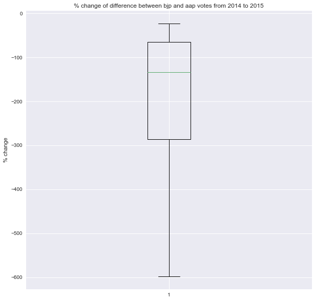

```python
plt.figure(figsize=(10,10))
plt.boxplot(df_bjp_aap_14_15["% change in diff 2015-2014"],whis=None,showfliers=False)
plt.title("% change of difference between bjp and aap votes from 2014 to 2015")
plt.ylabel("% change")
```

### Checking booths where in all 3 years, lead in votes has increased for AAP

```python
lead_inc=np.where((df_bjp_aap_13_14["% change in diff 2014-2013"]<0)&(df_bjp_aap_14_15["% change in diff 2015-2014"]<0))[0]
lead_inc+1
```

```
array([ 51,  96,  97, 129, 130, 138, 142], dtype=int64)
```

```python
print("Majority party in 2015 in these booths")
aap_inc=[]
for i in lead_inc:
    print(i+1,df_15.loc[i+1,"winner"])
    aap_inc.append(i+1)
```

```
Majority party in 2015 in these booths
51 AAP
96 AAP
97 AAP
129 AAP
130 AAP
138 AAP
142 AAP
```

#### ---------------------------------------------------------------------------------------------------------------------------------------------------------------

#### Implies, in these booths , lead of AAP has been increasing over the years and to the latest, AAP was in majority.

#### ---------------------------------------------------------------------------------------------------------------------------------------------------------------

### Booths where BJP was in majority in 2013 and had their lead (extra votes) increased further in 2014 ,but then suddenly lost their majority to AAP in 2015

```python
severe_bjp_change=np.where((df_bjp_aap_13_14["% change in diff 2014-2013"]>0)&(df_bjp_aap_14_15["% change in diff 2015-2014"]<=-100)&(df_bjp_aap_13_14["bjp-aap13"]>0))
print("Booths-",severe_bjp_change[0]+1)
```

```
Booths- [ 42 106 128 131 141]
```

#### --------------------------------------------------------------------------------------------------------------------------------------------------------------------

#### These booths would most - likely go in favour of AAP because of such a huge change in voting pattern against BJP

#### --------------------------------------------------------------------------------------------------------------------------------------------------------------------

### BJP losing in 2013, then getting support (with majority) in 2014 but again lost in 2015.

```python
bjp_reverse=np.where((df_bjp_aap_13_14["% change in diff 2014-2013"]>100)&(df_bjp_aap_14_15["% change in diff 2015-2014"]<=-100)&(df_bjp_aap_13_14["bjp-aap13"]<0))
bjp_reverse[0]+1
```

```
array([  1,   2,   3,   4,   5,   6,   7,   8,   9,  10,  14,  16,  17,
        18,  19,  20,  21,  41,  54,  55,  58,  59,  60,  61,  68,  73,
        74,  75,  76,  77,  78,  79,  80,  81,  82,  83,  84,  86,  87,
        89,  91,  92,  93,  94,  95,  98,  99, 100, 101, 102, 110, 111,
       112, 113, 115, 117, 132, 133, 134, 135, 136, 137, 139, 140, 143,
       144, 145, 146, 156], dtype=int64)
```

#### ----------------------------------------------------------------

#### These booths might also go in favour of AAP

#### ----------------------------------------------------------------

### Booths where bjp was lagging in 2013 and then gained support in 2014 but then went down again

```python
temp2=np.where((df_bjp_aap_13_14["% change in diff 2014-2013"]>100)&(df_bjp_aap_14_15["% change in diff 2015-2014"]>-100)&(df_bjp_aap_13_14["bjp-aap13"]<0))[0]
temp2+1
```

```
array([ 12,  13,  22,  23,  24,  25,  26,  27,  28,  30,  31,  32,  33,
        37,  38,  39,  46,  47,  50,  52,  53,  64,  65,  66,  67, 103,
       105, 107, 108, 109, 114, 116, 118, 119, 120, 124, 127, 147, 148,
       149, 150, 151, 153, 154, 155], dtype=int64)
```

#### These booths where bjp was behind AAP in 2013 but then came into majority in 2014 and finally lost votes in 2015 (though not enough to lose majority)

#### Checking votes increment of AAP in these booths from 2014 to 2015.

```python
print("Winner in these 45 booths")
df_15["winner"][temp2+1].value_counts()
```

```
Winner in these 45 booths
```

```
BJP    45
Name: winner, dtype: int64
```

```python
change_aap_14_15=(df_15.iloc[:,4]-df_14.iloc[:,1])*100/abs(df_14.iloc[:,1])
print(change_aap_14_15[temp2+1])
```

```
Booth Number
12      58.064516
13      59.659091
22      73.410405
23      75.590551
24      43.646409
25      60.975610
26      74.117647
27     121.568627
28      72.368421
30      99.354839
31     109.677419
32     101.724138
33     117.187500
37      95.054945
```

[output cut: 32 more lines]

#### Checking percentage votes in these booths

```python
percent_vote_aap_15=(df_15.iloc[:,4])*100/df_15.iloc[:,8]
percent_vote_aap_15[temp2+1]
```

```
Booth Number
12     33.164129
13     29.362591
22     38.022814
23     38.514680
24     38.922156
25     40.866873
26     36.453202
27     37.983193
28     40.061162
30     40.657895
31     36.585366
32     36.335404
33     39.714286
37     42.617047
```

[output cut: 32 more lines]

#### Booths where percentage of votes to aap was more than 40 and % change from 2014 to 2015 was more than 80%

```python
temp3=list(temp2[np.where((percent_vote_aap_15[temp2+1]>40)&(change_aap_14_15[temp2+1]>80))[0]]+1)
print(temp3)
```

```
[30, 37, 38, 47, 50, 147]
```

#### ---------------------------------------

#### In these booths, AAP might take over bjp

#### ---------------------------------------

```python
temp2_bjp=[]
for i in temp2+1:
    if i not in temp3:
        temp2_bjp.append(i)
```

```python
temp2_bjp
```

```
[12,
 13,
 22,
 23,
 24,
 25,
 26,
 27,
 28,
 31,
 32,
 33,
 39,
 46,
 52,
 53,
 64,
 65,
 66,
 67,
 103,
 105,
 107,
 108,
 109,
 114,
 116,
 118,
 119,
 120,
 124,
 127,
 148,
 149,
 150,
 151,
 153,
 154,
 155]
```

#### ----------------------------------------------------------------------------------------

#### These are booths where bjp might still continue to win in 2020

#### -----------------------------------------------------------------------------------------

### These are the booths where first for 2014, the lead of bjp increased but then the support dropped in 2015 but not that much that bjp lost its majority.

```python
temp=np.where((df_bjp_aap_13_14["% change in diff 2014-2013"]>0)&(df_bjp_aap_14_15["% change in diff 2015-2014"]>-100)&(df_bjp_aap_13_14["bjp-aap13"]>0))[0]
print("AAP taking booths from bjp(not majority) - " ,temp+1)
```

```
AAP taking booths from bjp(not majority) -  [ 11  29  34  35  36  40  43  44  45  56  57 104 121 122 123 125 126 152]
```

```python
print("Latest(2015) winner in these booths")
for i in temp:
    print(df_15.loc[i+1,"winner"],end=' ')
```

```
Latest(2015) winner in these booths
BJP BJP BJP BJP BJP BJP BJP BJP BJP BJP BJP BJP BJP BJP BJP BJP BJP BJP
```

#### We need to check if the lost votes went to AAP considerably or not.

```python
change_aap_14_15=(df_15.iloc[:,4]-df_14.iloc[:,1])*100/abs(df_14.iloc[:,1])
```

```python
print("Percentage change in AAP votes from 2014 to 2015 in these booths")
change_aap_14_15[temp+1]
```

```
Percentage change in AAP votes from 2014 to 2015 in these booths
```

```
Booth Number
11     112.500000
29      97.959184
34      87.037037
35      86.363636
36     113.953488
40     105.286344
43     106.535948
44      86.792453
45      61.428571
56      88.721805
57      80.373832
104     90.625000
121    117.142857
122     91.666667
123    114.634146
125     98.181818
126     98.734177
152     81.954887
dtype: float64
```

#### Checking percentage votes in these booths in 2015

```python
percent_vote_aap_15=(df_15.iloc[:,4])*100/df_15.iloc[:,8]
```

```python
percent_vote_aap_15[temp+1]
```

```
Booth Number
11     33.806818
29     33.975482
34     41.952233
35     38.389513
36     27.794562
40     46.047431
43     38.396112
44     36.940299
45     27.628362
56     33.964817
57     32.166667
104    28.638498
121    34.782609
122    36.149312
123    34.645669
125    32.200886
126    32.271326
152    35.021708
dtype: float64
```

#### Among these , those booths with vote percentage above 40 may take lead over bjp as they had a high % change in votes from the past election.

```python
(percent_vote_aap_15[temp+1]>40)
```

```
Booth Number
11     False
29     False
34      True
35     False
36     False
40      True
43     False
44     False
45     False
56     False
57     False
104    False
121    False
122    False
123    False
125    False
126    False
152    False
dtype: bool
```

```python
print("Booths where aap might take over - 34,40")
```

```
Booths where aap might take over - 34,40
```

```python
still_bjp=percent_vote_aap_15[temp+1].drop([34,40],axis=0).index
print("Booths where bjp might stil remain -\n",still_bjp.values)
```

```
Booths where bjp might stil remain -
 [ 11  29  35  36  43  44  45  56  57 104 121 122 123 125 126 152]
```

#### This is a subset of same party winning three years

```python
for i in temp:
    if i in same:
        print(i)
```

```
34
35
43
44
56
121
122
125
```

```python
count=0
for i in same:
    print(i,end=' ')
    count+=1
print("\n")

for i in aap_inc:
    print(i,end=' ')
    count+=1
print("\n")

for i in severe_bjp_change[0]+1:
    print(i,end=' ')
    count+=1
print("\n")


for i in bjp_reverse[0]+1:
    print(i,end=' ')
    count+=1
print("\n")


for i in temp3:
    print(i,end=' ')
    count+=1

print("\n")
for i in temp2_bjp:
    print(i,end=' ')
    count+=1

print("\n ",count)
```

```
11 15 29 34 35 36 40 43 44 45 48 49 56 57 62 63 69 70 71 72 85 88 90 104 121 122 123 125 126 152

51 96 97 129 130 138 142

42 106 128 131 141

1 2 3 4 5 6 7 8 9 10 14 16 17 18 19 20 21 41 54 55 58 59 60 61 68 73 74 75 76 77 78 79 80 81 82 83 84 86 87 89 91 92 93 94 95 98 99 100 101 102 110 111 112 113 115 117 132 133 134 135 136 137 139 140 143 144 145 146 156

30 37 38 47 50 147

12 13 22 23 24 25 26 27 28 31 32 33 39 46 52 53 64 65 66 67 103 105 107 108 109 114 116 118 119 120 124 127 148 149 150 151 153 154 155
  156
```

```python
for i in range(1,156):
    if i not in same+aap_inc+list(severe_bjp_change[0]+1)+list(bjp_reverse[0]+1)+list(temp2+1):
        print(i)
```

### Expected results for 2020 election

```python
booth_number=[]
expected_result=[]
```

```python
for i in same:
    booth_number.append(i)
    expected_result.append(df_15["winner"][i])
```

```python
for i in aap_inc:
    booth_number.append(i)
    expected_result.append("AAP")
```

```python
for i in severe_bjp_change[0]+1:
    booth_number.append(i)
    expected_result.append("AAP")
```

```python
for i in bjp_reverse[0]+1:
    booth_number.append(i)
    expected_result.append("AAP")
```

```python
for i in temp3:
    booth_number.append(i)
    expected_result.append("AAP")
```

```python
for i in temp2_bjp:
    booth_number.append(i)
    expected_result.append("BJP")
```

```python
Prediction=pd.DataFrame({"Booth number":booth_number,"Expected_Winner":expected_result})
```

```python
Prediction.sort_values(by='Booth number',inplace=True)
Prediction.set_index("Booth number",inplace=True)
with pd.option_context('display.max_rows', None, 'display.max_columns', None):  # more options can be specified also
    print(Prediction)
```

```
             Expected_Winner
Booth number
1                        AAP
2                        AAP
3                        AAP
4                        AAP
5                        AAP
6                        AAP
7                        AAP
8                        AAP
9                        AAP
10                       AAP
11                       BJP
12                       BJP
13                       BJP
```

[output cut: 143 more lines]

```python
print("Booth Counts per winner")
Prediction["Expected_Winner"].value_counts()
```

```
Booth Counts per winner
```

```
AAP    99
BJP    57
Name: Expected_Winner, dtype: int64
```